# DNA FISH spots distance calculations

- Show All Code
- Hide All Code
- View Source

Author

Martin Stortz/Gianluca Pegoraro

Published

November 5, 2025

###Load packages

### User variables input and settings specification

```r
GLOB_C <- "*nuclei_information_well*" # Pattern for Single Cell data files
GLOB_S <- "*spots_locations_well*" # Pattern for Single Spot data files

XY_RES <- 0.108 # pixel size in um
```

### Metadata: Experimental conditions and plate layout

Provide experimental conditions and plate layout

```r
# Provide experimental conditions in desired order:
light_levs <- c("No sg, Dark", "No sg, Light", "sgIDR3, Dark", "sgIDR3, Light", "sgTCF3, Dark", "sgTCF3, Light", "sgIDR3+TCF3, Dark", "sgIDR3+TCF3, Light")

plate_layout <- tibble(
  row = c(8L, 8L, 8L, 8L, 9L, 9L, 9L, 9L),
  column = c(5L, 6L, 19L, 20L, 5L, 6L, 19L, 20L),
  well_index = c("H5", "H6", "H19", "H20", "I5", "I6", "I19", "I20"),
  light = c("No sg, Dark", "sgIDR3, Dark", "No sg, Light", "sgIDR3, Light", "sgTCF3, Dark", "sgIDR3+TCF3, Dark", "sgTCF3, Light", "sgIDR3+TCF3, Light")
) |>
  mutate(light = factor(light, levels = light_levs))
```

###Download data if needed

###### Read cells and spots data

HITIPS output text files must be in the `data` directory and the file names must match the GLOB pattern.

### Read cells data

```r
cell_tbl <- dir_info("data",
  recurse = T,
  glob = GLOB_C
) |>
  filter(size > "1K") |>
  rowwise() |>
  reframe(fread(path), file_name = as.character(path)) |>
  mutate(well_index = paste0(LETTERS[row], column)) |>
  select(file_name, column, row, well_index,
    field_index, time_point, cell_index,
    area, solidity,
    x = `centroid-0`,
    y = `centroid-1`
  ) |>
  arrange(
    column, row, field_index,
    time_point, cell_index
  ) |>
  left_join(plate_layout, by = c("well_index", "row", "column"))

cell_tbl <- cell_tbl[!is.na(cell_tbl$light), ]
```

### Read spots data

```r
spots_tbl <- dir_info("data",
  recurse = T,
  glob = GLOB_S
) |>
  filter(size > "1K") |>
  rowwise() |>
  reframe(fread(path), file_name = as.character(path)) |>
  mutate(well_index = paste0(LETTERS[row], column)) |>
  select(file_name, column, row,
    well_index, field_index, time_point,
    cell_index, channel,
    spot_index = V1,
    x = x_location, y = y_location
  ) |>
  # Convert xy distances from pixels to microns
  mutate(across(x:y, list(mic = ~ .x * XY_RES))) |>
  # Filter out spots not in any nucleus
  filter(cell_index != 0) |>
  arrange(
    column, row, field_index,
    time_point, cell_index, channel
  ) |>
  left_join(plate_layout, by = c("well_index", "row", "column"))

spots_tbl <- spots_tbl[!is.na(spots_tbl$light), ]
```

### Filter cells by size and shape

```r
cell_filter_tbl <- cell_tbl |>
  filter(area >= 80, solidity >= 0.875)
```

### Spot number per cell calculations

```r
cell_n_spots_tbl <- spots_tbl |>
  group_by(
    column, row, well_index, light, field_index,
    time_point, cell_index, channel
  ) |>
  count() |>
  pivot_wider(
    names_from = channel,
    names_prefix = "n_spots_channel_",
    values_from = n,
    values_fill = 0
  ) |>
  ungroup()
```

### Filter cells by spot number

```r
#|
spot_filt_criterion <- quote(n_spots_channel_2 > 1 & n_spots_channel_2 == n_spots_channel_4) # set criterion for filtering

cell_n_spots_filt_tbl <- cell_n_spots_tbl |>
  semi_join(cell_filter_tbl, by = c(
    "row", "column", "well_index", "light", "field_index",
    "time_point", "cell_index"
  )) |>
  filter(!!spot_filt_criterion)
```

### Filter out spots according to previous cell filtering by size, shape and spot number

```r
spot_filt_tbl <- spots_tbl |>
  semi_join(cell_n_spots_filt_tbl,
    by = c(
      "column", "row", "field_index", "light",
      "time_point", "cell_index"
    )
  ) |>
  as.data.table()
```

*2D Spot distance calculations*

###Calculate distances between all possible spot pairs for each cell

```r
gf_dist_2D <- spot_filt_tbl[channel %in% 2:4, # Only  Red and Green spots
  reshape2::melt(
    SpatialTools::dist2(
      as.matrix(.SD[
        channel == 2,
        list(x_mic, y_mic)
      ]),
      as.matrix(.SD[
        channel == 4,
        list(x_mic, y_mic)
      ])
    ),
    value.name = "gf_dist"
  ),
  by = list(
    row,
    column,
    well_index,
    light,
    field_index,
    time_point,
    cell_index
  )
]

setnames(gf_dist_2D, c("Var1", "Var2"), c("g_index", "f_index"))
```

###Find minimum spot distance Minimum distance is calculated based on channel 4 spots as reference

```r
setkey(
  gf_dist_2D, row, column, well_index,
  field_index, time_point, cell_index, f_index
)

gf_dist_min_2D <- gf_dist_2D[, .SD[which.min(gf_dist), ],
  by = key(gf_dist_2D)
] |>
  left_join(select(cell_tbl, column:well_index, light, field_index:area),
    by = c(
      "column", "row",
      "well_index", "light", "field_index",
      "time_point", "cell_index"
    )
  ) |>
  # Filter out distances > 2 um
  filter(gf_dist <= 2)
```

### Per well summary calculations

Calculate fraction of close alleles

```r
overlap_dist <- 0.27 # Threshold distance (in um) for contacts

overlaps <- gf_dist_min_2D |>
  group_by(
    well_index, light,
    row, column
  ) |>
  summarize(close_alleles = mean(gf_dist < overlap_dist))
overlaps$light <- factor(overlaps$light, levels = c(light_levs))
```

Summarize the number of spots per cell data into well-level data.

```r
well_tbl_n_spots <- cell_n_spots_filt_tbl |>
  group_by(
    well_index, light,
    row, column
  ) |>
  summarise(N_cells = sum(!!spot_filt_criterion)) |>
  ungroup() |>
  select(
    row, column,
    well_index, light, N_cells
  ) |>
  arrange(
    well_index,
    row,
    column
  )
```

Summarize the spot distance level data into well-level data.

```r
well_tbl_gf_dist <- gf_dist_min_2D |>
  group_by(
    well_index, light,
    row, column
  ) |>
  summarise(across(
    c(gf_dist),
    list(
      mean = ~ mean(.x, rm.na = TRUE),
      median = ~ median(.x, rm.na = T)
    )
  )) |>
  ungroup() |>
  select(
    row, column, light,
    well_index, gf_dist_mean:gf_dist_median
  ) |>
  arrange(
    well_index,
    row,
    column
  )
```

Bring all the well-level data information together

```r
well_tbl <- well_tbl_n_spots |>
  left_join(well_tbl_gf_dist, by = c("row", "column", "well_index", "light")) |>
  left_join(overlaps, by = c("row", "column", "well_index", "light")) |>
  rename(
    Condition = light,
    mean_dist = gf_dist_mean,
    median_dist = gf_dist_median
  )
write.csv(well_tbl, "output/Summary_results.csv", row.names = FALSE)
```

### Violin plot of spot distances (left panel of Fig. 2D)

```
Ignoring unknown labels:
• colour : "Light"
```

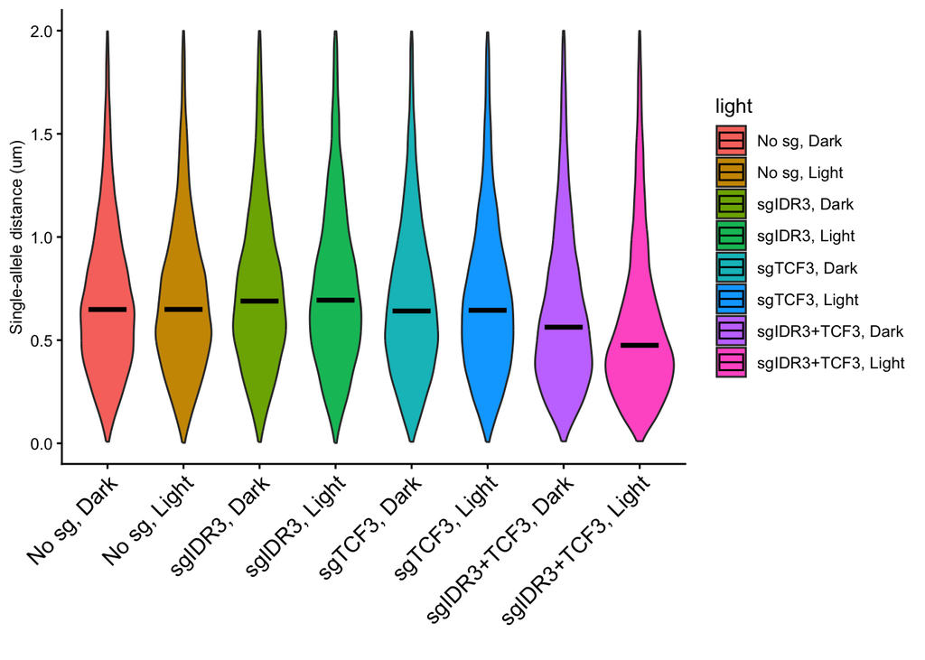

```r
gf_dist_min_2D$light <- factor(gf_dist_min_2D$light, levels = c(light_levs))
ggplot(gf_dist_min_2D, aes(x = light, y = gf_dist, fill = light)) +
  geom_violin() +
  stat_summary(fun = median, geom = "crossbar", width = 0.5, aes(group = light)) +
  ylim(c(0, 2)) +
  labs(x = "", y = "Single-allele distance (um)", color = "Light") +
  theme_classic() +
  theme(
    axis.text.x = element_text(size = 12, angle = 45, hjust = 1),
    axis.title = element_text(size = 9)
  )
```